# BMS31004 Bioinformatics for Biomedical Science - Week 3

Module Coordinator Mark Dunning

Last modified: 24 Feb 2022

# Module Overview

High-throughput sequencing is now established as a standard technique for many functional genomics studies; allowing the researcher to compare and contrast the transcriptomes of many individuals to obtain biological insight. A high-volume of data are generated from these experimental techniques and thus require robust and reproducible tools to be employed in the analysis.

In this module, you will be learning how to analyse RNA-seq count data, using R. This will include reading the data into R, quality control and performing differential expression analysis and gene set testing, with a focus on the well-respected DESEq2 analysis workflow. You will learn how to generate common plots for analysis and visualisation of gene expression data, such as boxplots and heatmaps.

Although we will use RNA-seq data as a case study, the format of the data and methodologies will be highly applicable to other types of high-throughput omics data.

# Introduction

Measuring gene expression on a genome-wide scale has become common practice over the last two decades or so, with microarrays predominantly used pre-2008. With the advent of next generation sequencing technology in 2008, an increasing number of scientists use this technology to measure and understand changes in gene expression in often complex systems. As sequencing costs have decreased, using RNA-Seq to simultaneously measure the expression of tens of thousands of genes for multiple samples has never been easier. The cost of these experiments has now moved from generating the data to storing and analysing it.

There are many steps involved in analysing an RNA-Seq experiment.

Analysing an RNAseq experiment begins with sequencing reads. Traditionally, these are aligned to a reference genome, then the number of reads mapped to each gene can be counted. More modern approaches such as `salmon` quantify transcripts directly and do not require genome alignment to have taken place. Either approach results in a table of counts, which is what we perform statistical analyses on in R. While mapping and counting are important and necessary tasks, they are typically performed in languages other than R and so outside the scope of this course.

In these sessions will be starting from the count data and getting straight into the analysis. We will be following a workflow that uses the `DESeq2` package.

## Additional Reading (**Optional**)

If you want more in-depth reading on DESeq2 and it’s usage, the following resources are available from the authors:-

- [DESeq2 User Guide](https://bioconductor.org/packages/release/bioc/vignettes/DESeq2/inst/doc/DESeq2.html)
- [RNA-seq workflow: gene-level exploratory analysis and differential expression](http://master.bioconductor.org/packages/release/workflows/vignettes/rnaseqGene/inst/doc/rnaseqGene.html)

# Learning objectives

- Configuring a new project in RStudio
- Exploring and navigating a file system using R commands rather than the GUI
- Importing RNA-seq counts via `tximport` and `DESeq2`
- How the representation of data in `DESeq2` differs from “tidy data”

### Example dataset

The data for this tutorial comes from the paper, [*Induction of fibroblast senescence generates a non-fibrogenic myofibroblast phenotype that differentially impacts on cancer prognosis.*](http://europepmc.org/article/MED/27992856).

> Cancer associated fibroblasts characterized by an myofibroblastic phenotype play a major role in the tumour microenvironment, being associated with poor prognosis. We found that this cell population is made in part by senescent fibroblasts in vivo. As senescent fibroblasts and myofibroblasts have been shown to share similar tumour promoting functions in vitro we compared the transcriptosomes of these two fibroblast types and performed RNA-seq of human foetal foreskin fibroblasts 2 (HFFF2) treated with 2ng/ml TGF-beta-1 to induce myofibroblast differentiation or 10Gy gamma irradiation to induce senescence. We isolated RNA 7 days upon this treatments changing the medium 3 days before the RNA extraction.

The sequencing reads for this experiment were uploaded to ArrayExpress [Sequencing Read Archive (SRA)](https://www.ebi.ac.uk/arrayexpress/experiments/E-MTAB-3101/) and processed using `salmon`. However, the workflow we will describe can be applied to other sources of count data.

# Project setup

As we learnt from the R introductory course, it is *good practice* to use a **Project** in RStudio to keep all the files belonging to the same analysis tidy and organised. If you haven’t done so already, download the files required for this module using the link below. There is no need to extract the files - this will occur when you upload the zip file to R workbench.

- BMS31004

A new project can be initiated using the **File -> New Project** menu option. Select that you want to create a New Directory

[figure not shown]

There are various options under Project Type, but we want **New Project**. You can specify any name you want, I am calling mine `BMS31004`

[figure not shown]

Once the RStudio window refreshes, you will have the option to upload some files.

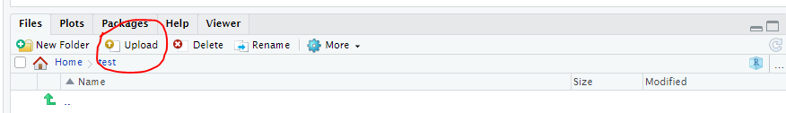

From the dialogue box that appears, click the **Choose file** button and select the file `BMS31004.zip` that you downloaded.

## Exploring the course directory, in R

The contents of the zip file should now be displayed in the bottom-right panel of RStudio.

[figure not shown]

We should check visually that the correct files are identified, but often we will need to obtain a list of file names, and their respective paths in R.

The `list.files` function from base R is a fundamental tool. As with all R functions, we can find out more using the help facility within RStudio

```r
?list.files
```

From the description we can see that the default operation is to list all the files within the current directory. The output is an R *vector*; one of R’s most fundamental data types.

```r
list.files()
```

This will print *all* the files in the directory. Sometimes we want files of a particular type (e.g. csv files that we can read into R). The `pattern` argument can be set to the name of a *file extension* that we are interested in.

```r
## List all files in the current directory that end in .csv
## We will revisit the tx2gene file shortly

list.files(pattern=".csv")
```

```
[1] "tx2gene.csv"
```

The `path` argument can also be changed to list the contents of other directories

```r
list.files(path = "meta_data/")
```

```
[1] "sampleInfo_corrected.txt" "sampleInfo.csv"
```

## Importing the metadata

We refer to *metadata* as the data that describes the biological and technical characteristics of the samples we have sequenced. Examples of variables recorded in the metadata might include.

- tumour / normal status
- cell line
- age
- gender
- date of collection
- litter

We include the sample groups that we want to compare, and any potential *confounding factors* that we might need to address as part of our quality assessment. The metadata is stored in a spreadsheet and typically entered by-hand. When creating such data we should be mindful of some best-practice guidelines that will make our data easier to read into R.

See here for a round-up of common errors to be avoiding when creating spreadsheets [Data Carpentry lesson on spreadsheet errors](https://datacarpentry.org/spreadsheet-ecology-lesson/02-common-mistakes/index.html)

```r
# Read the sample information into R
library(readr)
sampleinfo <- read_csv("meta_data/sampleInfo.csv")
sampleinfo
```

| Run | condition | Name | Replicate | Treated |
| --- | --- | --- | --- | --- |
| 1_CTR_BC_2 | CTR | CTR_1 | 1 | N |
| 2_TGF_BC_4 | TGF | TGF_1 | 1 | Y |
| 3_IR_BC_5 | IR | IR_1 | 1 | Y |
| 4_CTR_BC_6 | CTR | CTR_2 | 2 | N |
| 5_TGF_BC_7 | TGF | TGF_2 | 2 | Y |
| 6_IR_BC_12 | IR | IR_2 | 2 | Y |
| 7_CTR_BC_13 | ctr | CTR_3 | 3 | N |
| 8_TGF_BC_14 | tgf | TGF_3 | 3 | Y |
| 9_IR_BC_15 | ir | IR_3 | 3 | Y |

We will need to use this information later on in our analysis. Eventually we will be using the DESeq2 Bioconductor package for differential expression analysis. Before we do this, we will need to read our count files into R and do some pre-processing. The precise method of importing your count data into DESeq2 depends on the workflow used to generate the counts. The [DESeq2 vignette](https://bioconductor.org/packages/release/bioc/vignettes/DESeq2/inst/doc/DESeq2.html#input-data) gives many different use-cases.

## Inspecting the count files

The samples from this study have been *quantified* using `salmon`, which is beyond the scope of this workshop. The results of this tool can be found in the `salmon_quant` directory

```r
list.files(path = "salmon_quant/")
```

```
[1] "1_CTR_BC_2"  "2_TGF_BC_4"  "3_IR_BC_5"
[4] "4_CTR_BC_6"  "5_TGF_BC_7"  "6_IR_BC_12"
[7] "7_CTR_BC_13" "8_TGF_BC_14" "9_IR_BC_15"
```

Hence, you might see the code written in this way. The `/` at the end of the path is also not required.

```r
## a lazier way of listing the files in salmon_quant by not specifying the path argument.

list.files("salmon_quant")
```

```
[1] "1_CTR_BC_2"  "2_TGF_BC_4"  "3_IR_BC_5"
[4] "4_CTR_BC_6"  "5_TGF_BC_7"  "6_IR_BC_12"
[7] "7_CTR_BC_13" "8_TGF_BC_14" "9_IR_BC_15"
```

Both code chunks produce the same ouput - and it is not very useful if want to identify the files that we can read into R. The issue is that the count outputs are divided into different directories (based on sample name), and R will only list the contents of `salmon_quant` itself. Hence we will need to add an extra argument `recursive=TRUE` to tell R to look into the different sub-directories for files.

```r
quant_files <- list.files("salmon_quant/",recursive = TRUE)
quant_files
```

```
[1] "1_CTR_BC_2/quant.sf.gz"  "2_TGF_BC_4/quant.sf.gz"
[3] "3_IR_BC_5/quant.sf.gz"   "4_CTR_BC_6/quant.sf.gz"
[5] "5_TGF_BC_7/quant.sf.gz"  "6_IR_BC_12/quant.sf.gz"
[7] "7_CTR_BC_13/quant.sf.gz" "8_TGF_BC_14/quant.sf.gz"
[9] "9_IR_BC_15/quant.sf.gz"
```

Although we don’t strictly need to for this example, it is a good idea to add a `pattern` argument to the `list.files` command. This will only list file names that contain a particular pattern. In reality the output of `salmon` typically includes more than just the `quant.sf` files we have distributed for this course.

```r
quant_files <- list.files("salmon_quant/",
                          recursive = TRUE,
                          pattern="quant.sf.gz")
```

We have seen previously that functions such as `read_csv` and `read_tsv` can be used to read files into R. The `read_tsv` can be used in this case because the files are tab-delimited; even though they have unusual file extensions. The `.sf` file is particular to `salmon`, and the `.gz` means that the file is compressed. R is happy to read compressed files without any modification to the usual `read_tsv` code.

However, `read_tsv` is designed to read a *single* file at a time. To pick a particular file from the `quant_files` vector, we can use the `[]` notation in R. The number inside the `[]` is the *index* in the vector.

```r
## Print the name of the first file
quant_files[1]
```

```
[1] "1_CTR_BC_2/quant.sf.gz"
```

```r
## Print the name of the second file
quant_files[2]
```

```
[1] "2_TGF_BC_4/quant.sf.gz"
```

However, the `read_tsv` function doesn’t quite work as we expect.

**Exercise**: Can you explain the behaviour of output of running the code chunk below? Why can’t `read_tsv` find the file name specified?

```r
library(readr)
read_tsv(quant_files[1])
```

To correct this error we can use:-

```r
dirs <- list.files("salmon_quant/")
quant_files <- list.files("salmon_quant/",pattern="quant.sf.gz",recursive = TRUE,full.names = TRUE)

quant_files
```

```
[1] "salmon_quant//1_CTR_BC_2/quant.sf.gz"
[2] "salmon_quant//2_TGF_BC_4/quant.sf.gz"
[3] "salmon_quant//3_IR_BC_5/quant.sf.gz"
[4] "salmon_quant//4_CTR_BC_6/quant.sf.gz"
[5] "salmon_quant//5_TGF_BC_7/quant.sf.gz"
[6] "salmon_quant//6_IR_BC_12/quant.sf.gz"
[7] "salmon_quant//7_CTR_BC_13/quant.sf.gz"
[8] "salmon_quant//8_TGF_BC_14/quant.sf.gz"
[9] "salmon_quant//9_IR_BC_15/quant.sf.gz"
```

```r
read_tsv(quant_files[1])
```

| Name | Length | EffectiveLength | TPM | NumReads |
| --- | --- | --- | --- | --- |
| ENST00000456328 | 1657 | 1420.232 | 0.654676 | 82.886147 |
| ENST00000450305 | 632 | 378.699 | 0.000000 | 0.000000 |
| ENST00000488147 | 1351 | 1055.773 | 0.000000 | 0.000000 |
| ENST00000619216 | 68 | 3.000 | 55.550793 | 14.856194 |
| ENST00000473358 | 712 | 446.825 | 0.000000 | 0.000000 |
| ENST00000469289 | 535 | 288.521 | 0.000000 | 0.000000 |
| ENST00000607096 | 138 | 5.000 | 0.000000 | 0.000000 |
| ENST00000417324 | 1187 | 936.692 | 0.000000 | 0.000000 |
| ENST00000461467 | 590 | 338.128 | 0.000000 | 0.000000 |
| ENST00000606857 | 840 | 250.000 | 0.000000 | 0.000000 |

[output cut: 990 more lines]

The columns of interest here are `Name` and `NumReads` which are the transcript name and raw read counts respectively.

In theory, we *could* read each of these files and *join* them together using tools from `dplyr` (e.g. `left_join`). However, when it comes to reading files for Bioinformatics analyses there are usually packages available that will do the job far more efficiently than we could by-hand. The particular package we will using is called `tximport`. This package is often used as an intermediate step between `salmon` and `DESeq2`. In the case of `salmon` output, it performs a key pre-processing step.

```r
## Use col_names=FALSE, otherwise it will try and use the first row as headings
tx2gene <- read_csv("tx2gene.csv",col_names = FALSE)
head(tx2gene)
```

| X1 | X2 |
| --- | --- |
| ENST00000456328 | ENSG00000223972 |
| ENST00000450305 | ENSG00000223972 |
| ENST00000488147 | ENSG00000227232 |
| ENST00000619216 | ENSG00000278267 |
| ENST00000473358 | ENSG00000243485 |
| ENST00000469289 | ENSG00000243485 |

```r
library(tximport)
txi <- tximport(quant_files,type="salmon",tx2gene = tx2gene,ignoreTxVersion = TRUE)
```

```
reading in files with read_tsv
1 2 3 4 5 6 7 8 9
summarizing abundance
summarizing counts
summarizing length
```

The resulting object is a “*list*” structure in R. This type of data is when we want to store a dataset that comprises multiple complex objects.

The `names` function will show the types of data that are stored in the object

```r
names(txi)
```

```
[1] "abundance"           "counts"
[3] "length"              "countsFromAbundance"
```

The raw counts can be found using `txi$counts`. However, this will print *all* of the data to the screen. We can print the first few rows with the `head` function.

```r
head(txi$counts)
```

```
                     [,1]      [,2]      [,3]      [,4]
ENSG00000000003 1578.6121 1546.8929 1341.7545 1704.3403
ENSG00000000005    0.0000    0.0000    0.0000    0.0000
ENSG00000000419 1774.0000 1775.0000 1866.0000 1809.0000
ENSG00000000457  698.3618  617.0317  601.2624  733.4502
ENSG00000000460  246.3958  309.0028  115.6429  224.3013
ENSG00000000938   10.0000    5.0000   11.0000    6.0000
                     [,5]      [,6]      [,7]      [,8]
ENSG00000000003 1395.3670 1264.0522 1555.5059 1370.1367
ENSG00000000005    0.0000    0.0000    0.0000    0.0000
ENSG00000000419 1921.0000 1776.0000 1797.0000 1482.0000
ENSG00000000457  661.5251  537.4323  750.7308  593.2492
ENSG00000000460  255.0125  107.9939  245.1283  289.4327
ENSG00000000938    1.0000    2.0000   19.0000    4.0000
                     [,9]
ENSG00000000003 1268.6731
ENSG00000000005    1.0000
ENSG00000000419 1979.8812
ENSG00000000457  628.4068
ENSG00000000460  126.6161
ENSG00000000938    8.0000
```

The data is not particularly useful though as the *columns* of the count matrix above do not show the names of the samples. The sample names are important as we will relate these back to the biological groupings in the dataset. The column names will set from the `names` of the `quant_files` vector

```r
names(quant_files)
```

```r
## This is the the final version of the code used to read the raw counts into R

dirs <- list.files("salmon_quant/")
quant_files <- list.files("salmon_quant/",pattern="quant.sf.gz",recursive = TRUE,full.names = TRUE)
names(quant_files) <- dirs

## printing the code on multiple lines improves the readability

txi <- tximport(quant_files,
                type="salmon",
                tx2gene = tx2gene,
                ignoreTxVersion = TRUE)
```

```
reading in files with read_tsv
1 2 3 4 5 6 7 8 9
summarizing abundance
summarizing counts
summarizing length
```

Now the counts have meaningful column names

```r
head(txi$counts)
```

```
                1_CTR_BC_2 2_TGF_BC_4 3_IR_BC_5
ENSG00000000003  1578.6121  1546.8929 1341.7545
ENSG00000000005     0.0000     0.0000    0.0000
ENSG00000000419  1774.0000  1775.0000 1866.0000
ENSG00000000457   698.3618   617.0317  601.2624
ENSG00000000460   246.3958   309.0028  115.6429
ENSG00000000938    10.0000     5.0000   11.0000
                4_CTR_BC_6 5_TGF_BC_7 6_IR_BC_12
ENSG00000000003  1704.3403  1395.3670  1264.0522
ENSG00000000005     0.0000     0.0000     0.0000
ENSG00000000419  1809.0000  1921.0000  1776.0000
ENSG00000000457   733.4502   661.5251   537.4323
ENSG00000000460   224.3013   255.0125   107.9939
ENSG00000000938     6.0000     1.0000     2.0000
                7_CTR_BC_13 8_TGF_BC_14 9_IR_BC_15
ENSG00000000003   1555.5059   1370.1367  1268.6731
ENSG00000000005      0.0000      0.0000     1.0000
ENSG00000000419   1797.0000   1482.0000  1979.8812
ENSG00000000457    750.7308    593.2492   628.4068
ENSG00000000460    245.1283    289.4327   126.6161
ENSG00000000938     19.0000      4.0000     8.0000
```

# Starting to explore the count data

We will be using the `DESeq2` library to analyse this dataset. Along with the counts and metadata, a *design* for the experiment also needs to be specified. This will define how the differential expression analysis is carried out, but can be changed at a later stage so for now we will use `Treated` as our factor of interest.

Printing the contents of `dds` to the screen gives details of how the data are represented.

```r
library(DESeq2)
dds <- DESeqDataSetFromTximport(txi,
                                colData = sampleinfo,
                                design = ~Treated)
```

```
using counts and average transcript lengths from tximport
```

```r
dds$condition
```

```
[1] "CTR" "TGF" "IR"  "CTR" "TGF" "IR"  "ctr" "tgf" "ir"
```

```r
dds$Treated
```

```
[1] N Y Y N Y Y N Y Y
Levels: N Y
```

```r
head(counts(dds))
```

```
                1_CTR_BC_2 2_TGF_BC_4 3_IR_BC_5
ENSG00000000003       1579       1547      1342
ENSG00000000005          0          0         0
ENSG00000000419       1774       1775      1866
ENSG00000000457        698        617       601
ENSG00000000460        246        309       116
ENSG00000000938         10          5        11
                4_CTR_BC_6 5_TGF_BC_7 6_IR_BC_12
ENSG00000000003       1704       1395       1264
ENSG00000000005          0          0          0
ENSG00000000419       1809       1921       1776
ENSG00000000457        733        662        537
ENSG00000000460        224        255        108
ENSG00000000938          6          1          2
                7_CTR_BC_13 8_TGF_BC_14 9_IR_BC_15
ENSG00000000003        1556        1370       1269
ENSG00000000005           0           0          1
ENSG00000000419        1797        1482       1980
ENSG00000000457         751         593        628
ENSG00000000460         245         289        127
ENSG00000000938          19           4          8
```

On first inspection it might appear that the counts are stored in a data frame. If you ever need to check the data type of an object there a number of functions starting with the prefix `is.`. The data type is important as it will influence what functions can be used on the data. For instance, the `tidyverse` functions we have seen previously expect a data frame, and will not work on other data types

```r
is.data.frame(counts(dds))
```

```
[1] FALSE
```

```r
is.numeric(counts(dds))
```

```
[1] TRUE
```

So the object returned by `counts` is not a data frame. Therefore we cannot subset the data in the manner we are familiar with.

```r
dplyr::select(counts(dds), `1_CTR_BC_2`)
```

However, all is not lost because `DESeq2` includes some functions for accessing the data (as we will see later). The mechanism for accessing data from a count matrix is to use a pair of square brackets after the object name with the following convention `[row_number,column_number]`

```r
cm <- counts(dds)
## the count for the first gene on the first sample
cm[1,1]
```

```
[1] 1579
```

```r
## the count for the first gene on the second sample
cm[1,2]
```

```
[1] 1547
```

There are a few shortcuts if we want multiple rows (genes) and columns (samples)

```r
cm[1,1:3]
```

```
1_CTR_BC_2 2_TGF_BC_4  3_IR_BC_5
      1579       1547       1342
```

```r
cm[1:5,1:4]
```

```
                1_CTR_BC_2 2_TGF_BC_4 3_IR_BC_5
ENSG00000000003       1579       1547      1342
ENSG00000000005          0          0         0
ENSG00000000419       1774       1775      1866
ENSG00000000457        698        617       601
ENSG00000000460        246        309       116
                4_CTR_BC_6
ENSG00000000003       1704
ENSG00000000005          0
ENSG00000000419       1809
ENSG00000000457        733
ENSG00000000460        224
```

and finally, if want all the measurements for a particular gene.

```r
cm["ENSG00000000005",]
```

```
 1_CTR_BC_2  2_TGF_BC_4   3_IR_BC_5  4_CTR_BC_6
          0           0           0           0
 5_TGF_BC_7  6_IR_BC_12 7_CTR_BC_13 8_TGF_BC_14
          0           0           0           0
 9_IR_BC_15
          1
```

```r
cm[1,]
```

```
 1_CTR_BC_2  2_TGF_BC_4   3_IR_BC_5  4_CTR_BC_6
       1579        1547        1342        1704
 5_TGF_BC_7  6_IR_BC_12 7_CTR_BC_13 8_TGF_BC_14
       1395        1264        1556        1370
 9_IR_BC_15
       1269
```

`colData` will display the meta data that has been stored with the object.

```r
colData(dds)
```

```
DataFrame with 9 rows and 5 columns
                    Run   condition        Name
            <character> <character> <character>
1_CTR_BC_2   1_CTR_BC_2         CTR       CTR_1
2_TGF_BC_4   2_TGF_BC_4         TGF       TGF_1
3_IR_BC_5     3_IR_BC_5          IR        IR_1
4_CTR_BC_6   4_CTR_BC_6         CTR       CTR_2
5_TGF_BC_7   5_TGF_BC_7         TGF       TGF_2
6_IR_BC_12   6_IR_BC_12          IR        IR_2
7_CTR_BC_13 7_CTR_BC_13         ctr       CTR_3
8_TGF_BC_14 8_TGF_BC_14         tgf       TGF_3
9_IR_BC_15   9_IR_BC_15          ir        IR_3
            Replicate  Treated
            <numeric> <factor>
1_CTR_BC_2          1        N
2_TGF_BC_4          1        Y
3_IR_BC_5           1        Y
4_CTR_BC_6          2        N
5_TGF_BC_7          2        Y
6_IR_BC_12          2        Y
7_CTR_BC_13         3        N
8_TGF_BC_14         3        Y
9_IR_BC_15          3        Y
```

Individual columns from the metadata can also be accessed and printed using the `$` notation

```r
dds$condition
```

```
[1] "CTR" "TGF" "IR"  "CTR" "TGF" "IR"  "ctr" "tgf" "ir"
```

```r
dds$Treated
```

```
[1] N Y Y N Y Y N Y Y
Levels: N Y
```

The metadata columns can also be re-assigned. This useful in this case because we can see that `condition` is not stored as a factor, which could cause problems later-on when we want to use `condition` in the differential expression.

```r
dds$condition <- as.factor(dds$condition)
```

### Visualising library sizes

We can look at a few different plots to check that the data is good quality, and that the samples are behaving as we would expect. First, we can check how many reads we have for each sample in the `DESeqDataSet`. As we have seen, the counts themselves are accessed using the `counts` function; giving a matrix of counts. Going along the rows we will get the counts for a particular gene; and down each column are the counts for a given sample.

The sum of a particular column is therefore the total number of reads for that sample.

```r
sum(counts(dds)[,1])
```

```
[1] 37966475
```

A convenience function `colSums` exists for calculating the sum of each column in a matrix, returning a `vector` as a result.

```r
colSums(counts(dds))
```

```
 1_CTR_BC_2  2_TGF_BC_4   3_IR_BC_5  4_CTR_BC_6
   37966475    42302522    33300044    39401926
 5_TGF_BC_7  6_IR_BC_12 7_CTR_BC_13 8_TGF_BC_14
   37716438    32599790    34273169    38522207
 9_IR_BC_15
   36478271
```

The overall number of reads obtained for each sample is important, as it will influence how we interpret the number of reads for a given gene. If the number of reads for a particular gene is doubled from one sample to another we **cannot automatically assume that it’s expressed level is doubled**. In a similar manner, if the number of reads for a given gene is 0 we cannot assume that the gene is not expressed.

# Exercise

**Exercise**: - Use an appropriate function from `dplyr` to add a column containing the number of reads for each sample to the `sampleinfo` data frame. - Produce a bar plot to show the Millions of reads for each sample

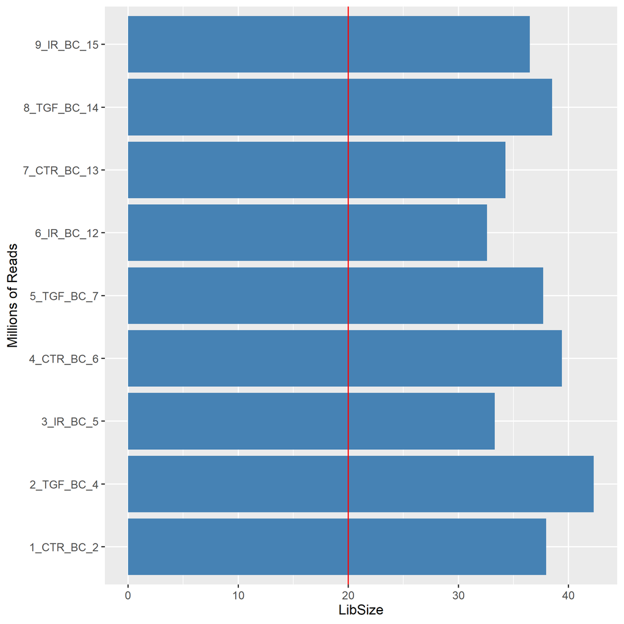

One of the main aims of the course is to encourage reproducibility via the use of R markdown files. For your assignment you will need to repeat some of the steps used in this workshop on a completely different dataset. However, some of steps performed in the workshop were to enhance our understanding of the data and do not need to be repeated each time.

# Exercise

**Exercise**: Create a new markdown files and include the following steps

- use `tximport` to read the salmon count files
- convert the `tximport` object into a `DESeqDataset`
- plot the number of reads for each sample

When you have created your markdown file, export it and send to one of our colleagues. Can they use the markdown file to create a report?

# Summary

- Importing a set of files into R involves being able to define the path to these files
- Specialised packages can be used to import data and store the data appropriately
- RNA-seq counts are stored in the form of a numeric matrix - which is different to the usual `tidyverse` representation of data.

See the below link to exercises relating to this weeks’ materials

- Exercises